# BDSD 2020: Introduction to ggplot2

## Dataset: Genotype Tissue Expression Study (v7)

Data is accessible from: https://gtexportal.org/home/datasets

The actual file is: https://storage.googleapis.com/gtex_analysis_v7/single_tissue_eqtl_data/GTEx_Analysis_v7_eQTL.tar.gz

The unzipped file contain information about eQTL from 48 tissues.  
Information includes:

1. Name of genetic variant
2. Name of gene
3. pval_nominal
4. slope

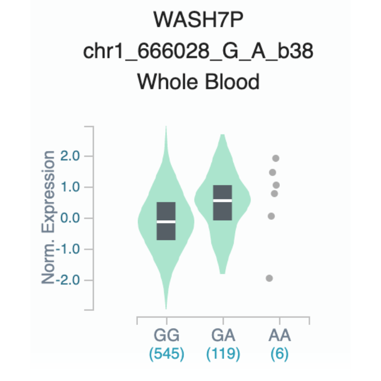

The data from each tissue has been read in and stored in three data.frames. The code to do this is here:

```r
dataDir <- "/Users/askol/Dropbox (Personal)/GTEx/V7/GTEx_Analysis_v7_eQTL/"
files <- dir(dataDir, pattern = "pairs")
tissues <- gsub("\\.v7.+","", files)
data <- list()

sampFile <- paste0(dataDir, "GTEx_Analysis_v8_Annotations_SampleAttributesDS.txt")
sampInfo <- read.table(file = sampFile, header=T, as.is=T, sep="\t", quote = "")
sampInfo <- sampInfo %>% mutate(ID = gsub("-.+-.+$","",SAMPID))
ID <- sapply(sampInfo$SAMPID, strsplit, split="-")
ID <- sapply(ID, function(x){paste(x[1],x[2], sep="-")})
ID <- unlist(ID)
sampInfo$ID <- ID
a <- sampInfo %>% distinct(ID, SMTSD)
tissueN <- table(sampInfo$SMTSD)
names(tissueN) <- gsub(" - " , "_" , names(tissueN))
names(tissueN) <- gsub(" " , "_" , names(tissueN))
names(tissueN) <- gsub("\\(" , "" , names(tissueN))
names(tissueN) <- gsub("\\)" , "" , names(tissueN))
names(tissueN) <- gsub("Cells_Cultured_fibroblasts",
                       "Cells_Transformed_fibroblasts",
                       names(tissueN))
tissueN <- as.data.frame(tissueN)
names(tissueN) <- c("tissue", "N")
saveRDS(file = "Data/sampleSize.rds", tissueN)

for (i in 1:length(files)){
    file <- paste0(dataDir, files[i])
    print(paste0("Reading file", file))
    data[[i]] <-  fread(file, header=T)
}

## collect p-values
ps <- data[[1]][,c("variant_id","symbol", "pval_nominal")] %>%
   mutate(chr = gsub("_.+","",variant_id)) %>% filter(chr %in% c(1,6,20))
ps <- ps %>% rename(!!tissues[1] := pval_nominal)

for (i in 2:length(data)){
  print(paste0("Mergeing ",tissues[i]))
  tmp <- data[[i]][, c("variant_id","symbol","pval_nominal")] %>%
    mutate(chr = gsub("_.+","",variant_id)) %>% filter(chr %in% c(1,6,20))
  tmp <- tmp %>% rename(!!tissues[i] := pval_nominal)
  ps <- full_join(ps, tmp, by=c("variant_id" , "symbol", "chr"))
}

## collect betas
betas <- data[[1]][,c("variant_id","symbol", "slope")] %>%
   mutate(chr = gsub("_.+","",variant_id)) %>% filter(chr %in% c(1,6,20))
betas <- betas %>% rename(!!tissues[1] := slope)

for (i in 2:length(data)){
  print(paste0("Mergeing ",tissues[i]))
  tmp <- data[[i]][, c("variant_id","symbol","slope")] %>%
   mutate(chr = gsub("_.+","",variant_id)) %>% filter(chr %in% c(1,6,20))
  tmp <- tmp %>% rename(!!tissues[i] := slope)
  betas <- full_join(betas, tmp, by=c("variant_id" , "symbol", "chr"))
}
## save ps
psFile <- paste0(dataDir, "ps.rds")
saveRDS(file = psFile, ps)

## save betas
betasFile = paste0(dataDir,"betas.rds")
saveRDS(file = betasFile, betas)
```

Let’s load the ps and betas variables

```r
betasFile = "Data/betas.rds"
psFile <- "Data/ps.rds"
nFile <- "Data/sampleSize.rds"
betas = readRDS(file = betasFile)
ps = readRDS(file = psFile)
tissueN = readRDS(file = nFile)

## substitute gene names for ensembl ids in ps and betas
betas <- betas %>% mutate(gene_id = gsub("\\..+","", gene_id))
betas <- left_join(betas, grch38[,c("ensgene","symbol")], by = c("gene_id" = "ensgene")) %>% mutate(symbol = ifelse(is.na(symbol), gene_id, symbol))

ps <- ps %>% mutate(gene_id = gsub("\\..+", "", gene_id))
ps <- left_join(ps, grch38[,c("ensgene","symbol")], by=c("gene_id" = "ensgene")) %>%
  mutate(symbol = ifelse(is.na(symbol), gene_id, symbol))
```

Now that we have some data to play with, we can start exploring how to perform some simple plotting functions using ggplot2.

## Number of eQTL as a function of tissue

```r
neqtl <- ps %>% select(-chr, -variant_id, -gene_id, -symbol)
neqtl <- colSums(!is.na(neqtl))
neqtl <- data.frame(tissue = names(neqtl), neqtl = neqtl)
```

Plots created with ggplot start with defining the dataset and the variables that will make up the x and y axis. This is done using the ggplot function, defining data, and the aesthetic variables (aes).

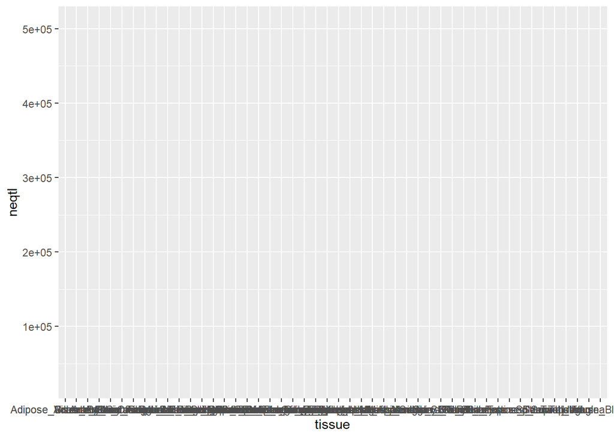

```r
options(width=100)
p <- ggplot(data=neqtl, aes(x=tissue, y=neqtl))
plot(p)
```

Next we add the geom_ ‘function’ that defines the type of plot. Here we use geom_bar, because we want to make a barplot. These functions take arguments that are specific to the plot type and graphical elements specific to the plot.

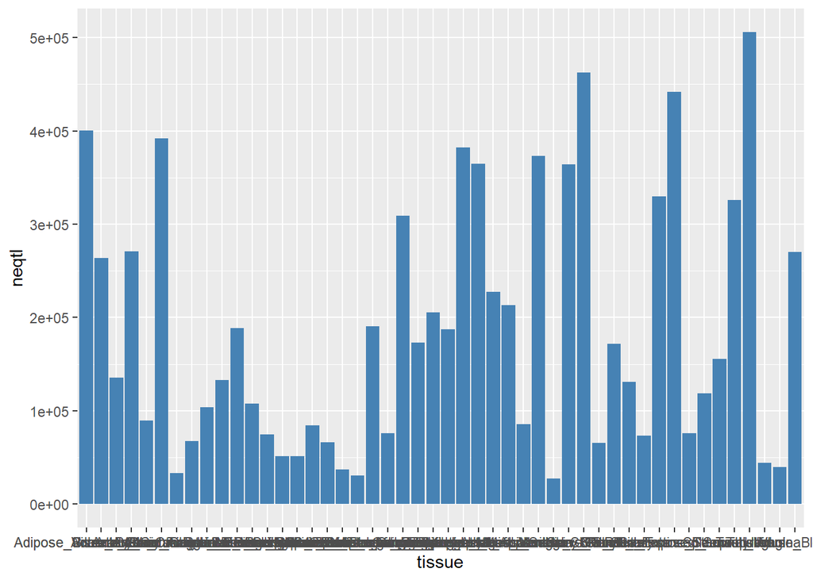

```r
options(width=100)
p <- p + geom_bar(stat="identity", fill = "steelblue")
print(p)
```

stat=“identity” means that the value in the data.frame is the value to be plotted. The default is stat=“count”, in which case it will count the number of elements in the data.frame column.

There are a few things that we can do to make this plot look nicer.

1. I find the grey background unattractive. There are predefined themes that provide alternatives. The one I use often is theme_minimal.
2. Angle the x-axis labels (tissues) so that they are legible.
3. Rename the x- and y-axis.

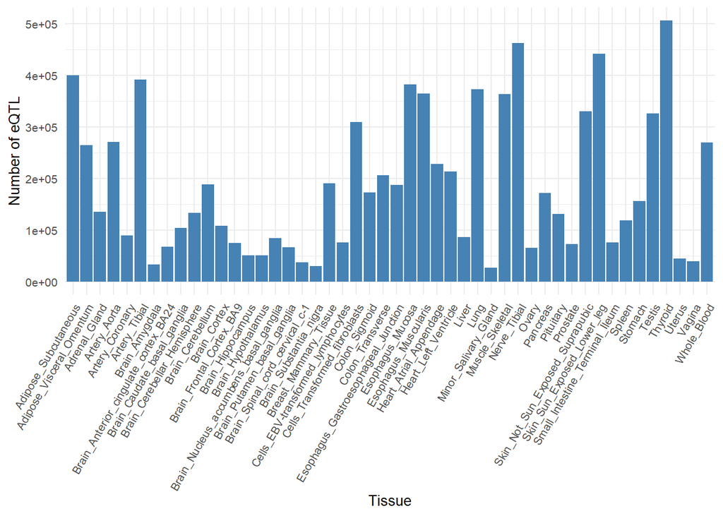

```r
options(width=100)
p <- ggplot(data=neqtl, aes(x=tissue, y=neqtl)) +
  geom_bar(stat="identity", fill = "steelblue") +
  theme_minimal() +
  theme(text=element_text(size=10),
        axis.text.x=element_text(angle=60, hjust=1)) +
  xlab("Tissue") +
  ylab("Number of eQTL")
  print(p)
```

One nice thing about ggplot is that the plot can be added to over multiple commands. This allows conditional statement to help determine what will be contained in the plot.

### Sorting factor variables and overlaying plots

One challenge of plotting categorical variables is deciding how to order them on the x-axis in a meaningful or attractive manner. Here, because different tissues have different numbers of samples, it may be reasonable to organize the tissues by samples size. First, we’ll merge the eqtl number data with the sample size data.

```r
neqtl <- left_join(neqtl, tissueN, by="tissue")
neqtl$tissue <- factor(neqtl$tissue,
                       levels = neqtl$tissue[order(neqtl$N, decreasing = T)])
```

Next we repeat the plot above.

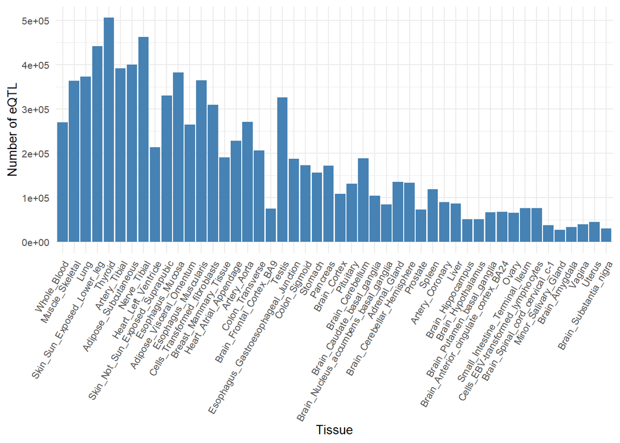

```r
options(width=100)
p <- ggplot(neqtl, aes(x=tissue, y=neqtl)) +
  geom_bar(stat="identity", fill = "steelblue") +
  theme_minimal() +
  theme(text=element_text(size=10),
        axis.text.x=element_text(angle=60, hjust=1)) +
  xlab("Tissue") +
  ylab("Number of eQTL")
print(p)
```

O.k. That’s much better. But if we really want to know the relationship between sample size and the number of eQTL, then let’s plot the number of samples of each tissue type on the same plot. To do this we have to do two things. First is to plot the sample size. We’ll use geom_points to do this. The other thing, is that scale of the number of eQTL and number of samples is quite different.

```r
range(tissueN$N)
```

```
## [1]    4 3288
```

```r
range(neqtl$neqtl)
```

```
## [1]  27146 505772
```

```r
factorN <- 494913/3288
```

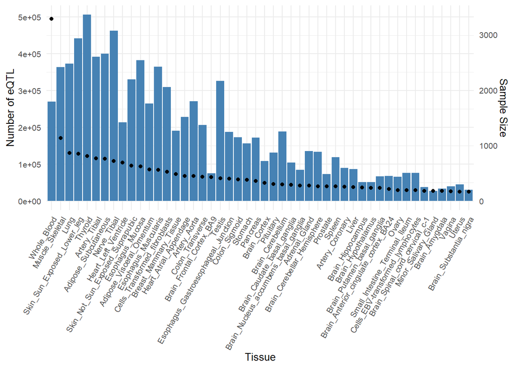

```r
options(width=100)
p <- p + geom_point(aes(x=tissue, y=N*factorN)) +
  scale_y_continuous(sec.axis = sec_axis(~./factorN, name = "Sample Size"))
print(p)
```

## Distributions

Now we’ll consider the effect sizes of eQTL in order to see how to plot distributions (the relative frequence of the variable’s values). Let’s first use the histogram to look at the distribution of eQTL effects. To make things simpler, and to demonstrate how to compare distributions, we will focus on two tissues: “Skeletal Muscle and Subcutaneous Adipose”

```r
TissSel <- c("Muscle_Skeletal", "Adipose_Subcutaneous")
bs <- betas %>% select(!!TissSel)
bs <- bs[rowSums(!is.na(bs)) > 0,]
bs <- as.data.table(bs)
bs <- melt(bs, measure=1:2, variable.name="tissue", value.name = "beta", na.rm=TRUE)
```

The function `melt` is very important for preparing data for `ggplot`. It transforms a data.frame from a wide rectangle to a long rectangle, whereby a subset of the column headers are converted to a column of values (specificied by variable.name), and the values in the converted columns are converted to another column (specificed by value.name). If there are columns that are not to be “longified” they are specified by id.vars.

```r
betas[1:4,TissSel]
```

```
##   Muscle_Skeletal Adipose_Subcutaneous
## 1              NA             0.914962
## 2              NA             0.705560
## 3              NA             0.271740
## 4              NA            -0.804681
```

This is what the transformation looks like for the data that were going to be plotting:

```r
bs[1:4,]
```

```
##             tissue      beta
## 1: Muscle_Skeletal -0.687663
## 2: Muscle_Skeletal -1.175840
## 3: Muscle_Skeletal -1.235690
## 4: Muscle_Skeletal -1.269570
```

A histrogram of the distribution of all the values is created using `geom_hist`

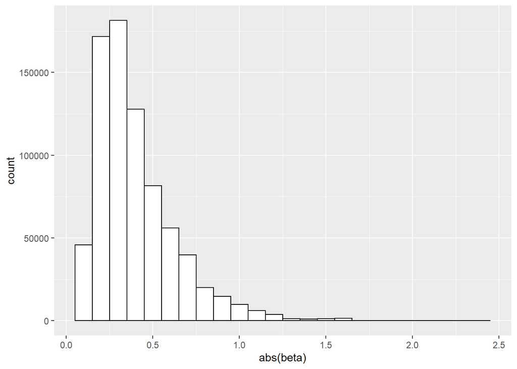

```r
options(width=100)
p <- ggplot(data=bs, aes(x = abs(beta))) +
  geom_histogram(binwidth=.1, colour="black", fill="white")
print(p)
```

If you prefer density functions, you can use `geom_density`

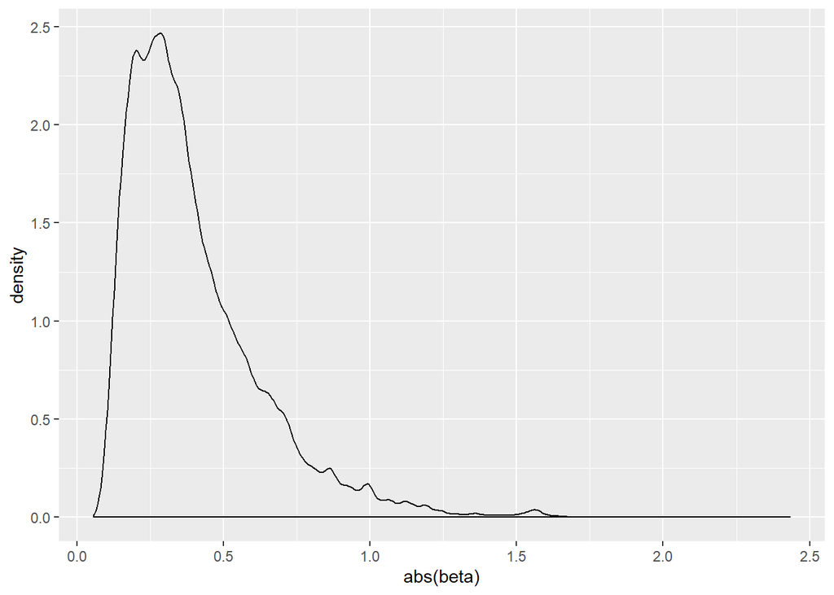

```r
p <- ggplot(bs, aes(x = abs(beta))) + geom_density(adjust = 1.15)
print(p)
```

What we really wanted to do was compare the distribution of effect sizes for different tissue types. To do this, we will use the fill attribute of the density function that is avalable within the `ggplot` function (or the `geom_density` function)

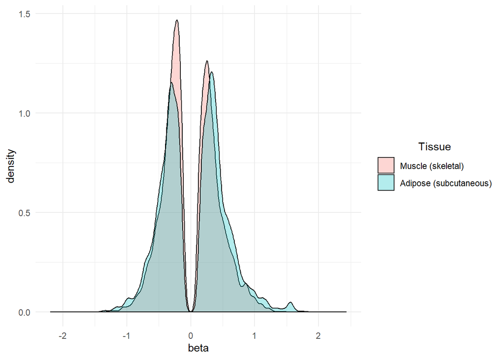

```r
options(width=100)
p <- ggplot(bs, aes(x=beta, fill=tissue)) + geom_density(alpha=.3) +
  scale_fill_discrete(name = "Tissue", labels=c("Muscle (skeletal)", "Adipose (subcutaneous)")) +
  theme_minimal() + theme(legend.title.align=0.5)
print(p)
```

## Boxplots and violin plots What if we wanted to compare more than two tissues. It’s not hard to imagine that looking at more than 2 or 3 tissues via overlapping densities will start to get ugly and uninformative very quickly. An alternative is to use a box and wisker plot. First we will select a subset of tssues and create an appropriately formated `data.frame`. We will also summarize the eQTL effects by gene, by calculating the mean eQTL effect for each gene.

```r
tissSel <- c("symbol", "Adipose_Subcutaneous",
             "Brain_Frontal_Cortex_BA9",
             "Breast_Mammary_Tissue","Colon_Transverse", "Esophagus_Mucosa",
             "Heart_Left_Ventricle","Liver", "Lung", "Muscle_Skeletal",
             "Spleen", "Skin_Sun_Exposed_Lower_leg","Stomach")
tissueNabrv <- tissueN[tissueN$tissue %in% tissSel,]
tissueNabrv$tissue <- droplevels(tissueNabrv$tissue)
tissueNabrv$tissue <- factor(tissueNabrv$tissue, levels =
                               tissueNabrv$tissue[order(tissueNabrv$N,
                                                        decreasing=TRUE)])
bs <- betas %>% select(chr, !!tissSel) %>% as.data.table()
bs <- melt(bs, measure=3:length(tissSel), id = 1:2,
           variable.name="tissue", value.name="beta")
bs <- bs %>% group_by(symbol, tissue) %>%
  mutate(m.beta=mean(beta, na.rm=T)) %>% filter(row_number() == 1) %>%
  select(-beta) %>% ungroup()
bs <- bs %>% filter(!is.na(m.beta)) %>%
  mutate(tissue = factor(tissue, levels = levels(tissueNabrv$tissue)))
```

Now we will plot these gene-based mean eQTL effect sizes across tissues.

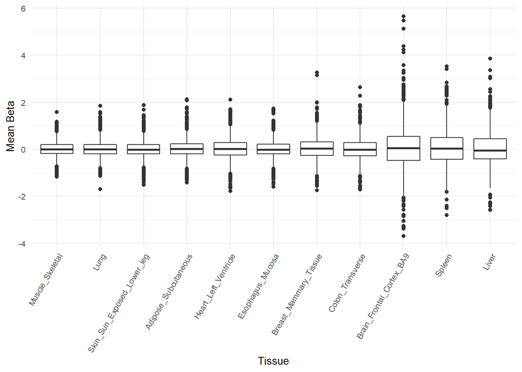

```r
options(width=120)
p <- ggplot(bs, aes(x = tissue, y = m.beta)) +
  geom_boxplot() + theme_minimal() +
  theme(text=element_text(size=10),
        axis.text.x=element_text(angle=60, hjust=1)) +
  xlab("Tissue") +
  ylab("Mean Beta")

print(p)
```

Now, what if we wanted to know if the effect size distribution differs by chromosomal location. To do this, we can use another aesthitic attribute. In this case we’ll use the fill attribute.

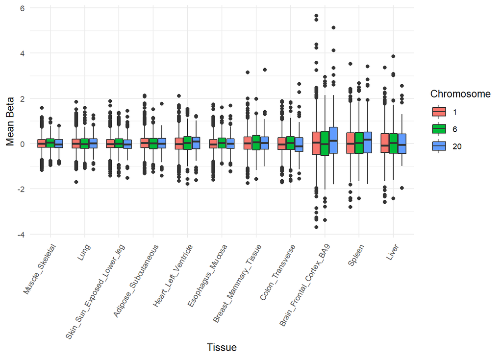

```r
bs$chr <- factor(bs$chr, levels = c("1","6","20"))
options(width=120)
p <- ggplot(bs, aes(x = tissue, y = m.beta, fill = chr)) +
  geom_boxplot() + theme_minimal() +
  theme(text=element_text(size=10),
        axis.text.x=element_text(angle=60, hjust=1)) +
  xlab("Tissue") +
  ylab("Mean Beta") +
  scale_fill_discrete(name = "Chromosome")

print(p)
```

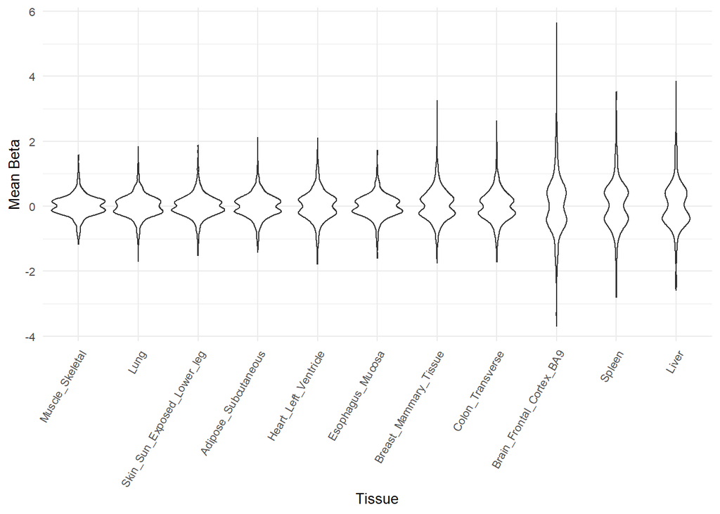

```r
p <- ggplot(bs, aes(x = tissue, y = m.beta)) +
  geom_violin() + theme_minimal() +
  theme(text=element_text(size=10),
        axis.text.x=element_text(angle=60, hjust=1)) +
  xlab("Tissue") +
  ylab("Mean Beta")

print(p)
```

It is not uncommon to plot the points on top of the violins. Our data happens to have a very large number of points. In order to “thin” out the data, we can use the `alpha` parameter in the `geom_jitter` function.

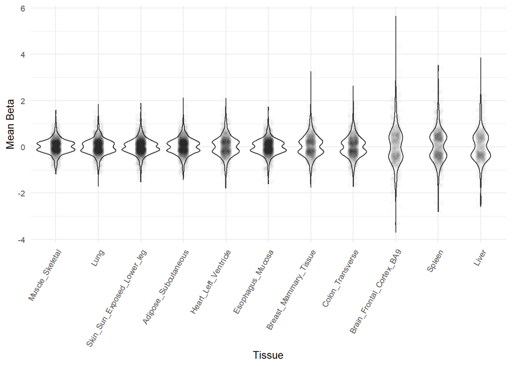

```r
p <- p + geom_jitter(width = 0.1, alpha=.01)
print(p)
```

## Adding text to plots

ggplot makes adding labels to plots pretty easy. As an example, let’s label the genes that have the larges and smallest value in each tissue on each chromosome. First, it’s useful to identify the minimum and maximum value for each tissue/chromosome.

```r
bs <- bs %>% group_by(tissue, chr) %>%
  mutate(min.lab = ifelse(m.beta == min(m.beta), gsub("ENSG0+","", symbol), ""),
         max.lab = ifelse(m.beta == max(m.beta), gsub("ENSG0+","", symbol), ""),
         lab = ifelse(m.beta %in% c(max(m.beta), min(m.beta)),
                                    gsub("ENSG0+","", symbol), ""))
```

Now we use `geom_text`.

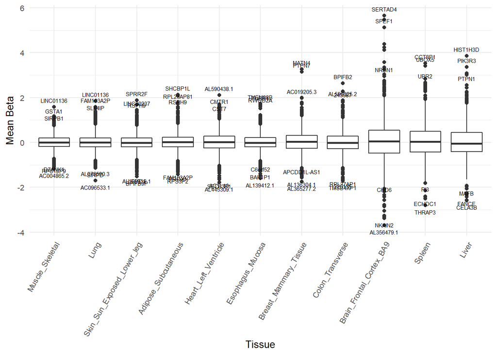

```r
options(width=120)
p <- ggplot(bs, aes(x = tissue, y = m.beta)) +
  geom_boxplot() +
  geom_text(aes(label = max.lab), size = 2, angle=0, vjust=-1) +
  geom_text(aes(label = min.lab), size = 2, angle=0, vjust=2) +
  theme_minimal() +
  theme(text=element_text(size=10),
        axis.text.x=element_text(angle=60, hjust=1)) +
  xlab("Tissue") +
  ylab("Mean Beta")

print(p)
```

When points are this close together, it’s really trick to get the labels to look nice. There is a fantastic package called `repel` which can help. Here’s how you use it.

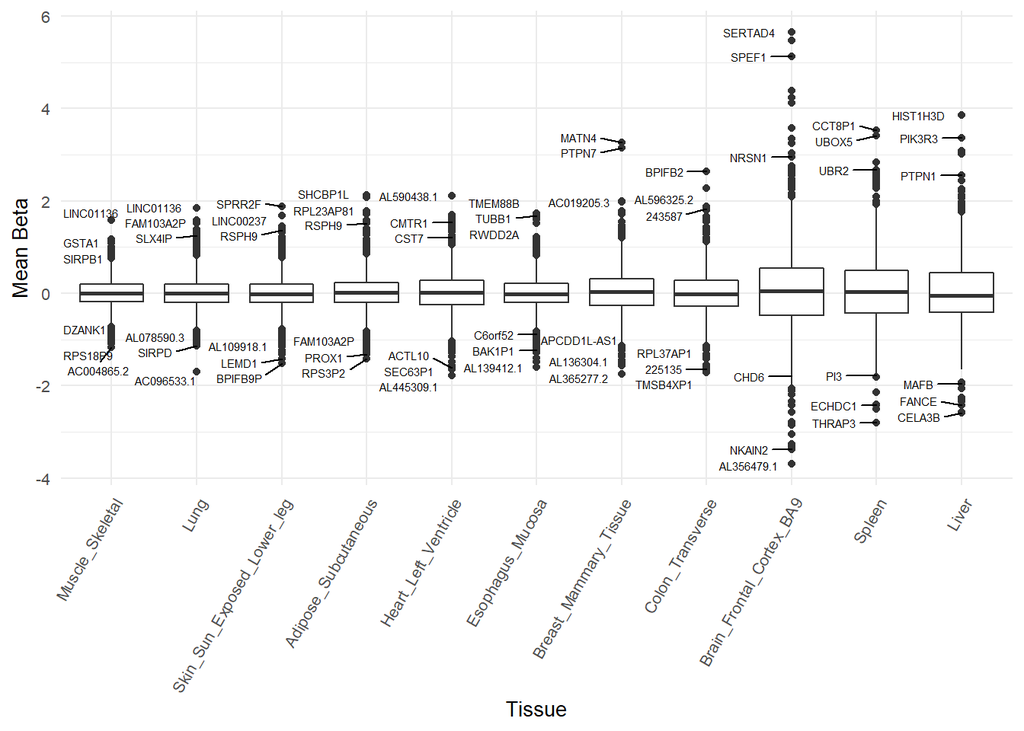

```r
options(width=120)
p <- ggplot(bs, aes(x = tissue, y = m.beta)) +
  geom_boxplot() +
  geom_text_repel(data = bs, aes(label = max.lab), size = 2, box.padding = .1,
                  nudge_x=-.5, angle=0) +
   geom_text_repel(data = bs, aes(label = min.lab), size = 2, box.padding = .1,
                  nudge_x=-.5, angle=0) +
  theme_minimal() +
  theme(text=element_text(size=10),
        axis.text.x=element_text(angle=60, hjust=1)) +
  xlab("Tissue") +
  ylab("Mean Beta")

print(p)
```

## Creating a matrix of plots to simply plotting multiple variables per plot

Recall our boxplot that printed the distribution of betas for chromosomes 1, 6 and 20 next to each other. As you can image, if we labelled gene names on that plot it would be a mess. For this reason, and others, sometimes it is better to repeat a simpler plot multiple times as a function of an addition variable (e.g. chromosome) in an organized way. One way to do this is to use `facet_grid`. First, in order to make the plot look a little nicer we will add “chr” to the front of the chromosome number.

```r
bs$chr <- factor(paste0("chr", bs$chr), levels = c("chr1","chr6","chr20"))
```

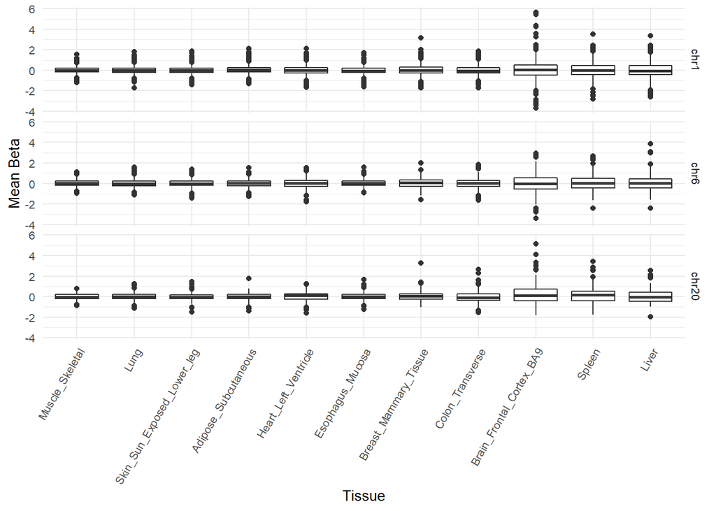

```r
options(width=120)
p <- ggplot(bs, aes(x = tissue, y = m.beta)) +
  geom_boxplot() +
  facet_grid(chr~.) +
  theme_minimal() +
  theme(text=element_text(size=10),
        axis.text.x=element_text(angle=60, hjust=1)) +
  xlab("Tissue") +
  ylab("Mean Beta")

print(p)
```

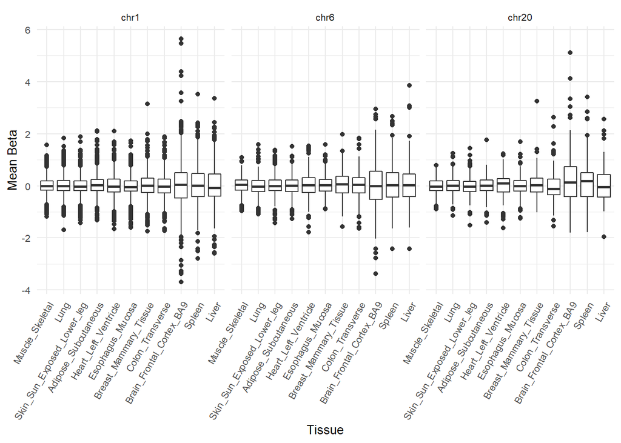

```r
options(width=120)
p <- ggplot(bs, aes(x = tissue, y = m.beta)) +
  geom_boxplot() +
  facet_grid(.~chr) +
  theme_minimal() +
  theme(text=element_text(size=10),
        axis.text.x=element_text(angle=60, hjust=1)) +
  xlab("Tissue") +
  ylab("Mean Beta")

print(p)
```

## Plotting similarity Next we are going to explore heatmaps, which are useful for comparing the pairwise correlation or other similarity measures between variables. For our data, we will calculate the proportion of eQTL shared between tissues. We can do this using the `ps` data frame which has tissues as columns, variant-gene combinations as rows, and each cell contains a p-value is the variant-gene is an eQTL for the tissue and NA otherwise. We will turn these into counts in the following way:

```r
tissSel <- c("Adipose_Subcutaneous",
             "Brain_Frontal_Cortex_BA9",
             "Breast_Mammary_Tissue","Colon_Transverse", "Esophagus_Mucosa",
             "Heart_Left_Ventricle","Liver", "Lung", "Muscle_Skeletal",
             "Spleen", "Skin_Sun_Exposed_Lower_leg","Stomach")
tissim <- ps[, tissSel]
tissim <- tissim[rowSums(!is.na(tissim)) > 0 , ]
tissim <- 1*(is.na(tissim) == FALSE)
tissim <- Matrix(tissim, sparse=T)

tisNshare <- t(tissim) %*% tissim
tisNeither<- nrow(tissim) - t(tissim == 0) %*% (tissim == 0)
tisShareProp <- tisNshare/tisNeither
tisShareProp <- as.matrix(tisShareProp)
tisShareProp <- as.data.table(tisShareProp, stringAsFactor=FALSE)
tisShareProp$Tissue1 <- names(tisShareProp)

toplot <- melt(tisShareProp, id = "Tissue1",  variable.name="Tissue2", value.name = "PropShare")
toplot <- toplot %>% mutate(Tissue1 = factor(Tissue1, levels=names(tisShareProp)),
                            Tissue2 = factor(Tissue2, levels=names(tisShareProp)))
toplot <- toplot %>% filter(Tissue1 != Tissue2)
```

O.k. Now that we’ve calculate the proportion of eQTL that tissue pairs share in common, we can plot them in a number of ways. One simple way is to use a scatter plot.

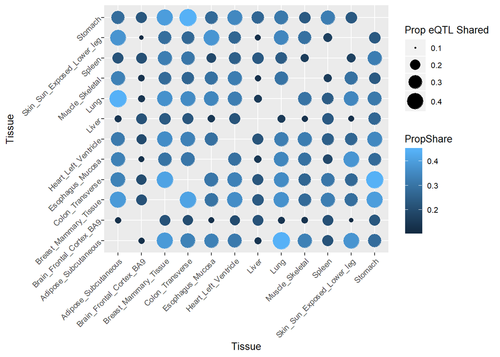

```r
p <- ggplot(toplot, aes(x=Tissue1, y=Tissue2)) +
  geom_point(aes(size = PropShare, color = PropShare)) +
  scale_size_continuous(name = "Prop eQTL Shared",
                      range=c(.5,8),
                      limits=c(.1,.45)) +
  theme(axis.text.x = element_text(angle = 45),
        text=element_text(size=10, hjust=1),
        axis.text.y = element_text(angle = 45),
        axis.title = element_text(hjust=.5)) +
  xlab("Tissue") + ylab("Tissue")

  ## COLOR LABELS TO HELP IDENTIFY WHO IS WHO ##
  #theme(axis.text.x = element_text(angle = 90, color = STclr)) +
  #scale_color_manual(values=clrLvl)
print(p)
```

A more common alternative for plotting similarity data is a heatmap. The way to make a heatmap using ggplot is using `geom_tile`, although many folks prefer alternative heatmapping functions. We’ll explore one of them shortly. `Geom_tile` works very much like all other geom type functions. . .

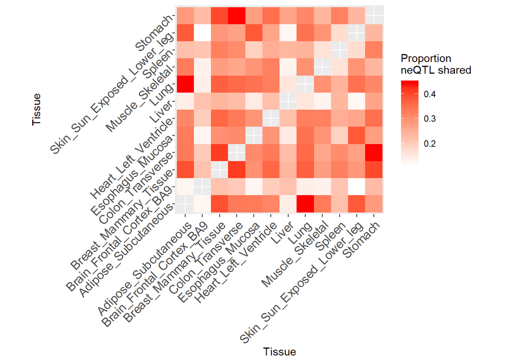

```r
p <- ggplot(toplot, aes(x=Tissue1, y=Tissue2)) +
  geom_tile(aes(fill = PropShare)) +
   theme(axis.text.x = element_text(angle = 45),
        axis.text=element_text(size=12, hjust=1),
        axis.text.y = element_text(angle = 45),
        axis.title = element_text(hjust=.5)) +
  coord_equal() +
  scale_fill_gradient(name = "Proportion\nneQTL shared",
                      low = "white", high = "red") +
  xlab("Tissue") + ylab("Tissue")
print(p)
```

Sometimes it’s nice to add the actual value in the cell (provided the matrix isn’t too large)

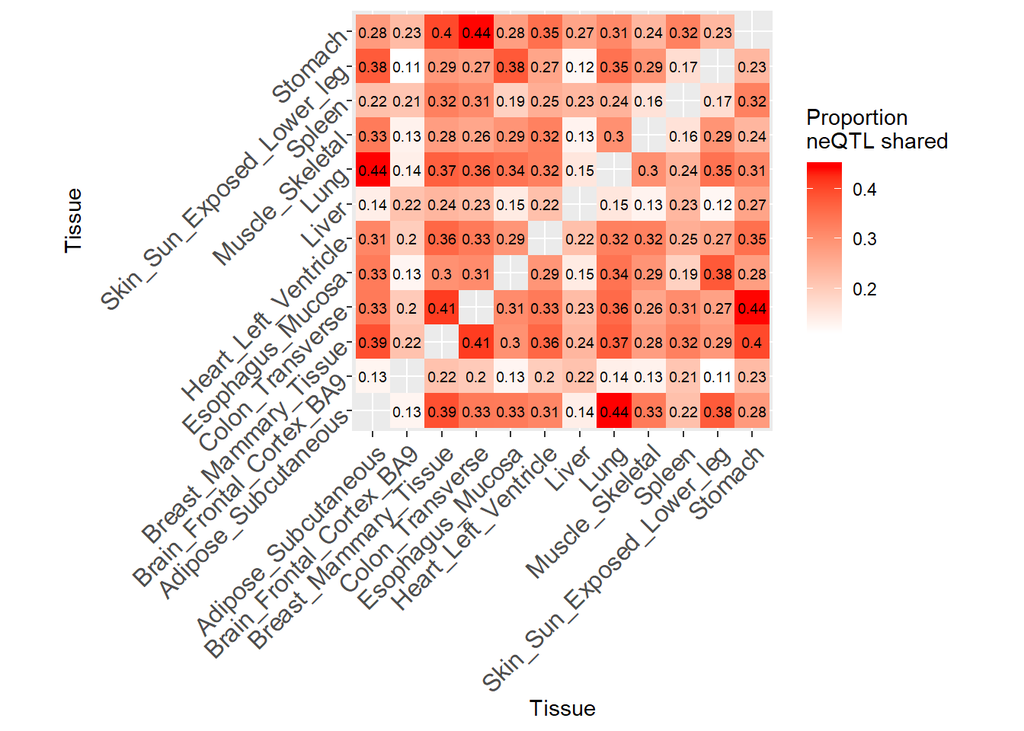

```r
p <- p <- ggplot(toplot, aes(x=Tissue1, y=Tissue2)) +
  geom_tile(aes(fill = PropShare)) +
   theme(axis.text.x = element_text(angle = 45),
        axis.text=element_text(size=12, hjust=1),
        axis.text.y = element_text(angle = 45),
        axis.title = element_text(hjust=.5)) +
  coord_equal() +
  scale_fill_gradient(name = "Proportion\nneQTL shared",
                      low = "white", high = "red") +
  xlab("Tissue") + ylab("Tissue") +
  geom_text(aes(label = as.character(round(PropShare, 2))),
            size = 2.5)

print(p)
```

The other common need when plotting similarities is to organize the columns and rows so as to show patterns, which makes interpretting and communicating your results easier. To do this, we will introduce a new heatmap package called `pheatmap`. `pheatmap` expects the data to be in a matrix form. We can use the complementary function to `melt` called `cast`. It works like this:

```r
tp2 <- reshape2::dcast(toplot, Tissue1 ~ Tissue2,
                       value.var = "PropShare")
  rownames(tp2) <- tp2$Tissue1
tp2 <- tp2 %>% select(-Tissue1) %>% as.matrix()
tp2[1:4,1:4]
```

```
##                          Adipose_Subcutaneous Brain_Frontal_Cortex_BA9 Breast_Mammary_Tissue Colon_Transverse
## Adipose_Subcutaneous                       NA                0.1268428             0.3908484        0.3338619
## Brain_Frontal_Cortex_BA9            0.1268428                       NA             0.2155646        0.2012800
## Breast_Mammary_Tissue               0.3908484                0.2155646                    NA        0.4123290
## Colon_Transverse                    0.3338619                0.2012800             0.4123290               NA
```

O.k. Now we will plot using pheatmap.

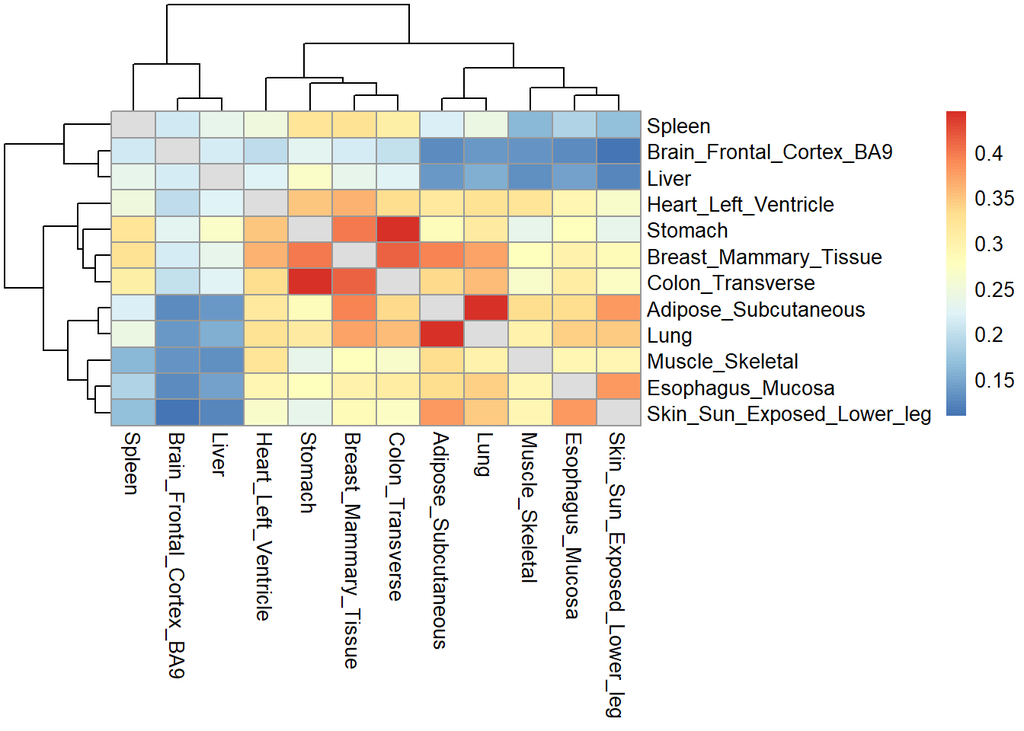

```r
pheatmap(tp2)
```

While the cladogram is informative, this might be a more attractive plot without it.

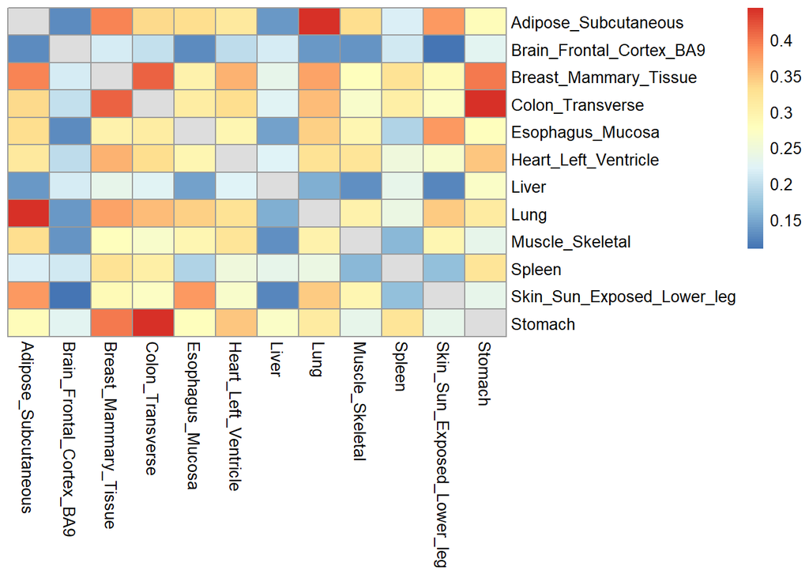

```r
pheatmap(tp2, cluster_rows=FALSE, cluster_cols=FALSE)
```